# Project: Investigating GapMinder Energy and Emission Data

- Introduction
- Data Wrangling
- Exploratory Data Analysis
- Conclusions

# Introduction

**Energy transition has become a global topical issue since the continous effect of greenhouse emission to the climate. Since the Paris agreement agenda, it is expected that many nations should begin to take measures to transition from fossil fuels which is the primary source of C02 in the atmosphere.**

**Energy data has been collected from gapminder in other to be informed about the energy consumption of nations, the amount of emission generated and their population. The data set contains countries' total populations, energy use per person, c02 emision per person, and the total oil produced if the country is an oil producing country. The data collected is for year 2000 and 2010, showing a 10-year span. The analysis is assuming a reference year of 2010.**

**This analysis should answer the following questions:**

### Q1: Do countries with higher population release more of the global emission per person?

### Q2: Are the non oil producing countries emitting lesser C02 than the oil producing regons?

### Q3: How many countries have become more energy efficient since the last 10 years?

### Q4: Which country has had the greatest emission drop for the last 10 years?

### Q5: What are the features of a high energy consuming nation?

```python
# importing data and packages
import pandas as pd
import numpy as np
import matplotlib.pyplot as plt
%matplotlib inline
```

## Data Wrangling

```python
# Data load
df_population = pd.read_csv("population_total.csv")
df_ener_pp = pd.read_csv("energy_use_per_person.csv")
df_oil_prd = pd.read_csv("oil_production_total.csv")
df_C02_ems = pd.read_csv("co2_emissions_tonnes_per_person.csv")
```

Current data sets contains many years. We are only interested in year (2000) and (2010) for the four data sets.

### Data Filtering

```python
label = ['country','2000','2010']
df_C02_ems = df_C02_ems[label]
df_ener_pp = df_ener_pp[label]
df_population = df_population[label]
df_oil_prd = df_oil_prd[label]
```

The data needs to be aranged and merged into two different years (2000 and 2010) containing the five different variables as a singular dataframe.

```python
from functools import reduce

#list of DataFrames
dfs = [df_C02_ems, df_ener_pp, df_population,df_oil_prd]

#merging all as one
df_merge = reduce(lambda  left,right: pd.merge(left,right,on=['country'],
                                            how='outer'), dfs)
```

```python
#check merge output
df_merge.head()
```

|  | country | 2000_x | 2010_x | 2000_y | 2010_y | 2000_x | 2010_x | 2000_y | 2010_y |
| --- | --- | --- | --- | --- | --- | --- | --- | --- | --- |
| 0 | Afghanistan | 0.037 | 0.29 | NaN | NaN | 20800000.0 | 29200000.0 | NaN | NaN |
| 1 | Angola | 0.581 | 1.24 | 439.0 | 521.0 | 16400000.0 | 23400000.0 | 36900000.0 | 88900000.0 |
| 2 | Albania | 0.966 | 1.56 | 580.0 | 729.0 | 3130000.0 | 2950000.0 | NaN | NaN |
| 3 | Andorra | 8.020 | 6.12 | NaN | NaN | 65400.0 | 84500.0 | NaN | NaN |
| 4 | United Arab Emirates | 35.700 | 18.30 | 10100.0 | 7220.0 | 3130000.0 | 8550000.0 | 122000000.0 | 135000000.0 |

```python
#filter data for year 2000
df_2000 = df_merge.drop(['2010_x','2010_y'], axis = 1)

#rename columns
new_labels = ['country','co2_emission_per_person','energy_use_per_person','total_population','total_oil_produce']
df_2000.columns = new_labels

#check
df_2000.head()
```

|  | country | co2_emission_per_person | energy_use_per_person | total_population | total_oil_produce |
| --- | --- | --- | --- | --- | --- |
| 0 | Afghanistan | 0.037 | NaN | 20800000.0 | NaN |
| 1 | Angola | 0.581 | 439.0 | 16400000.0 | 36900000.0 |
| 2 | Albania | 0.966 | 580.0 | 3130000.0 | NaN |
| 3 | Andorra | 8.020 | NaN | 65400.0 | NaN |
| 4 | United Arab Emirates | 35.700 | 10100.0 | 3130000.0 | 122000000.0 |

```python
#filter data for year 2010
df_2010 = df_merge.drop(['2000_x','2000_y'], axis = 1)

#rename columns
new_labels = ['country','co2_emission_per_person','energy_use_per_person','total_population','total_oil_produce']
df_2010.columns = new_labels

#check
df_2010.head()
```

|  | country | co2_emission_per_person | energy_use_per_person | total_population | total_oil_produce |
| --- | --- | --- | --- | --- | --- |
| 0 | Afghanistan | 0.29 | NaN | 29200000.0 | NaN |
| 1 | Angola | 1.24 | 521.0 | 23400000.0 | 88900000.0 |
| 2 | Albania | 1.56 | 729.0 | 2950000.0 | NaN |
| 3 | Andorra | 6.12 | NaN | 84500.0 | NaN |
| 4 | United Arab Emirates | 18.30 | 7220.0 | 8550000.0 | 135000000.0 |

```python
#ascertain column labels are identical for both years
(df_2000.columns == df_2010.columns).all()
```

```
True
```

```python
#view dimension of data set 2000
df_2000.shape
```

```
(201, 5)
```

```python
df_2000.dtypes
```

```
country                     object
co2_emission_per_person    float64
energy_use_per_person      float64
total_population           float64
total_oil_produce          float64
dtype: object
```

```python
#view dimension of data set 2010
df_2010.shape
```

```
(201, 5)
```

## Check Data Properties & Attend to Null Values

```python
#check for missing values
df_2000.isnull().sum()
```

```
country                      0
co2_emission_per_person      8
energy_use_per_person       61
total_population             4
total_oil_produce          154
dtype: int64
```

```python
df_2010.isnull().sum()
```

```
country                      0
co2_emission_per_person      7
energy_use_per_person       60
total_population             4
total_oil_produce          153
dtype: int64
```

**For year 2000, 8 countries do not have recorded C02 emission values, the median would be used to fill nulls.**

**61 countries are absent in the energy use data, the median would be used to fill nulls.**

**Non-oil producing countries would be assigned a zero value to total oil produce.**

**For year 2010, 7 countries do not have recorded C02 emission values, the median would be used to fill nulls.**

**60 countries are absent in the energy use data, the median would be used to fill nulls.**

**Non-oil producing countries would be assigned a zero value to total oil produce.**

```python
#replace year 2000 C02 emission nulls with median value
median = df_2000.co2_emission_per_person.median()
df_2000['co2_emission_per_person'] = df_2000['co2_emission_per_person'].fillna(median)
df_2000.co2_emission_per_person.isnull().sum()
```

```
0
```

```python
#replace year 2010 C02 emission nulls with median value
median = df_2000.co2_emission_per_person.median()
df_2010['co2_emission_per_person'] = df_2010['co2_emission_per_person'].fillna(median)
df_2010.co2_emission_per_person.isnull().sum()
```

```
0
```

```python
#replace year 2000 energy use nulls with median value
median = df_2000.energy_use_per_person.median()
df_2000['energy_use_per_person'] = df_2000['energy_use_per_person'].fillna(median)
df_2000.energy_use_per_person.isnull().sum()
```

```
0
```

```python
#replace year 2010 energy use nulls with median value
median = df_2010.energy_use_per_person.median()
df_2010['energy_use_per_person'] = df_2010['energy_use_per_person'].fillna(median)
df_2010.energy_use_per_person.isnull().sum()
```

```
0
```

```python
#replace year 2000 total population nulls with mean value
mean = df_2000.total_population .mean()
df_2000['total_population'] = df_2000['total_population'].fillna(mean)
df_2000.total_population.isnull().sum()
```

```
0
```

```python
#replace year 2010 total population nulls with mean value
mean = df_2010.total_population .mean()
df_2010['total_population'] = df_2010['total_population'].fillna(mean)
df_2010.total_population.isnull().sum()
```

```
0
```

```python
#replace year 2000 total_oil_produce nulls with zeroes
value = 0
df_2000['total_oil_produce'] = df_2000['total_oil_produce'].fillna(value)
df_2000.total_oil_produce.isnull().sum()
```

```
0
```

```python
#replace year 2010 total_oil_produce nulls with zeroes
value = 0
df_2010['total_oil_produce'] = df_2010['total_oil_produce'].fillna(value)
df_2010.total_oil_produce.isnull().sum()
```

```
0
```

```python
#check data types
df_2000.dtypes
```

```
country                     object
co2_emission_per_person    float64
energy_use_per_person      float64
total_population           float64
total_oil_produce          float64
dtype: object
```

```python
#confirm data types are similar
(df_2000.dtypes == df_2010.dtypes).all()
```

```
True
```

```python
#view data
df_2000.head()
```

|  | country | co2_emission_per_person | energy_use_per_person | total_population | total_oil_produce |
| --- | --- | --- | --- | --- | --- |
| 0 | Afghanistan | 0.037 | 1240.0 | 20800000.0 | 0.0 |
| 1 | Angola | 0.581 | 439.0 | 16400000.0 | 36900000.0 |
| 2 | Albania | 0.966 | 580.0 | 3130000.0 | 0.0 |
| 3 | Andorra | 8.020 | 1240.0 | 65400.0 | 0.0 |
| 4 | United Arab Emirates | 35.700 | 10100.0 | 3130000.0 | 122000000.0 |

```python
#view data
df_2010.head()
```

|  | country | co2_emission_per_person | energy_use_per_person | total_population | total_oil_produce |
| --- | --- | --- | --- | --- | --- |
| 0 | Afghanistan | 0.29 | 1470.0 | 29200000.0 | 0.0 |
| 1 | Angola | 1.24 | 521.0 | 23400000.0 | 88900000.0 |
| 2 | Albania | 1.56 | 729.0 | 2950000.0 | 0.0 |
| 3 | Andorra | 6.12 | 1470.0 | 84500.0 | 0.0 |
| 4 | United Arab Emirates | 18.30 | 7220.0 | 8550000.0 | 135000000.0 |

## Exploratory Data Analysis

### Exploring With Visuals

**An Histogram is plotted below to show the distributions of the data features for year 2000 and 2010: co2_emission_per_person, energy_use_per_person, total_population and total_oil_produce**

**Energy use per person and Co2 emission per person appear skewed to the right for both years showing that the mean of both data sets is pulled to the right with more lower values.**

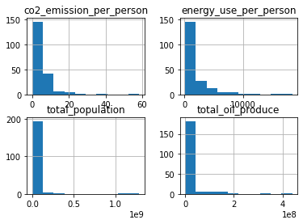

```python
df_2000.hist();
```

```python
df_2010.hist();
```

[output not shown]

### **Scatter plots are drawn below to show the relationship between two continous variables**

**Scatter plot showing relationship between co2_emission_per_person and total_population for year 2000 and 2010**

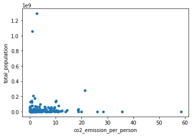

```python
df_2000.plot(x = 'co2_emission_per_person', y = 'total_population', kind ='scatter')
```

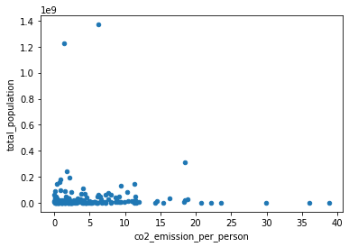

```python
df_2010.plot(x = 'co2_emission_per_person', y = 'total_population', kind ='scatter')
```

**Scatter plot showing relationship between energy_use_per_person and total_population for year 2000 and 2010**

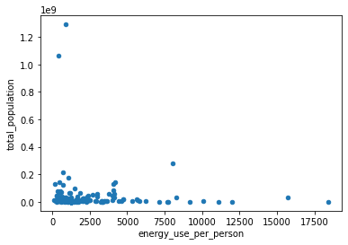

```python
df_2000.plot(x = 'energy_use_per_person', y = 'total_population', kind ='scatter')
```

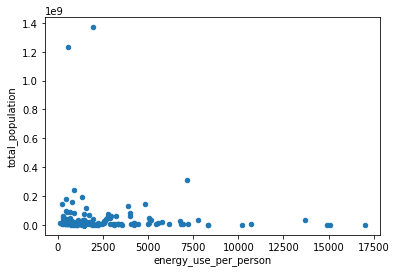

```python
df_2010.plot(x = 'energy_use_per_person', y = 'total_population', kind ='scatter')
```

**Scatter plot showing relationship between energy_use_per_person and co2_emission_per_person for year 2000 and 2010**

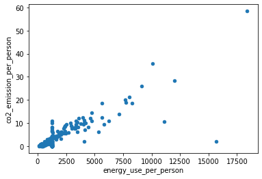

```python
df_2000.plot(x = 'energy_use_per_person', y = 'co2_emission_per_person', kind ='scatter')
```

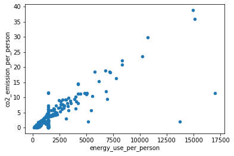

```python
df_2010.plot(x = 'energy_use_per_person', y = 'co2_emission_per_person', kind ='scatter')
```

**From above scatter plots, there seem to be a positive correlation between C02 Emission and Energy Use. An increase in energy use per person is an increase in the c02 emission, and a decrease in the energy usage is also a reduction in c02 emission.**

### Question 1: Do countries with higher population release more of the global emission per person?

**We would like to know if the amount of emission per person in a location is a function of the total population resident in a particular country. In answering this question, the population data would be categorized into four levels: Low, Moderate, High and Highly Densed in ascending order of magnitude. And then the average c02 emission for each population category is estimated**

```python
#Classify populations ( Low, Moderate,high,Highly-dense)
df_2010['total_population'].describe()
```

```
count    2.010000e+02
mean     3.525691e+07
std      1.338143e+08
min      7.830000e+02
25%      1.860000e+06
50%      7.810000e+06
75%      2.480000e+07
max      1.370000e+09
Name: total_population, dtype: float64
```

**The population classification is done using the quartile ranges of the total_population distribution. The first lower 25% represents the 'low population', the next 25% up to the median as 'moderate population', next 25% as 'high population', and the next 25% up to the maximum as 'highly-densed population**

```python
low_population = df_2010.query('1.86e+06 > total_population >= 7.83e+02')
mod_population = df_2010.query('7.81e+06 > total_population >=1.86e+06')
high_population = df_2010.query('2.48e+07 > total_population >=7.81e+06')
hdense_population = df_2010.query('1.37e+09 >= total_population >=2.48e+07')
```

```python
#confirming sample counts equals sum of category counts
num_samples = df_2010.shape[0]
num_samples ==low_population['co2_emission_per_person'].count() + mod_population['co2_emission_per_person'].count() + high_population['co2_emission_per_person'].count() + hdense_population['co2_emission_per_person'].count()
```

```
True
```

```python
#calculating average emission per population size
low_pop_emm = low_population['co2_emission_per_person'].mean()
mod_pop_emm = mod_population['co2_emission_per_person'].mean()
high_pop_emm = high_population['co2_emission_per_person'].mean()
hdense_pop_emm = hdense_population['co2_emission_per_person'].mean()
print("Population Size: Average C02 Emission Per Person")
print("Low: ",low_pop_emm," Moderate: ",mod_pop_emm," High: ",high_pop_emm," Highly-Densed: ",hdense_pop_emm)
```

```
Population Size: Average C02 Emission Per Person
Low:  5.071899999999999  Moderate:  5.252878000000002  High:  3.664628  Highly-Densed:  4.538799999999999
```

**From the result above, the average c02 emission per person in a low populated country (population size less than 1.86 million) is about 5.07 tonnes. The average c02 emission per person in a moderately populated country (population size between 1.86 million and 7.81 million) is estimated as 5.25 tonnes. A high population size of between 7.81 millon and 24.8 million have an estimated value of 3.66 tonnes of c02 emission per person whereas a highly dense population size of between 24.8 million and 1.37billion have an estimated value of 4.54 tonnes of c02 emission per person**

**A bar chart to visualize the individual population category c02 emission is presented below**

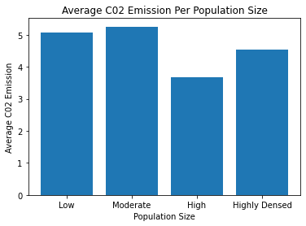

```python
#creating bar chart
locations = [1,2,3,4]
heights = [low_pop_emm,mod_pop_emm,high_pop_emm,hdense_pop_emm]
labels = ['Low', 'Moderate', 'High', 'Highly Densed']
plt.bar(locations,heights, tick_label = labels)
plt.title('Average C02 Emission Per Population Size')
plt.xlabel('Population Size')
plt.ylabel('Average C02 Emission')
```

**This results suggest that the c02 emission per person isn't particularly tied to the population as it is possible for a low population country to emit more c02 per person than a higher population. This statistics may buttress the idea that a high populated region has the tendency to be more energy efficient.**

### Question 2: Are the non oil producing countries emitting lesser C02 than the oil producing regons?

**We would like to know if the oil producing countries are really emitting more C02 in the atmosphere than the non-oil producing countries. Since oil is a fossil fuel which is major cause of C02 emission globally, it is neccessary to know if the majority of C02 emission is from oil producing countries.**

**The countries are splitted into two, oil-producing, and non oil-producing countries. The average emission per person per country category is thus estimated.**

```python
#generate oil producing and non -oil producing country dataframe
oil_country = df_2010.query('total_oil_produce > 0')
no_oil_country = df_2010.query('total_oil_produce < 1')

#confirming sample counts equals sum of category counts
num_samples ==oil_country['total_oil_produce'].count() + no_oil_country['total_oil_produce'].count()
```

```
True
```

```python
#calculating average emission per oil production
oil_country_emm = oil_country['co2_emission_per_person'].mean()
no_oil_country_emm = no_oil_country['co2_emission_per_person'].mean()
print('oil producing: ',oil_country_emm,'   non oil producing: ',no_oil_country_emm)
```

```
oil producing:  8.445675    non oil producing:  3.4350111111111072
```

**The average emission per person in an oil producing country is about 8.45 tonnes while the average emission per person in a non oil-producing country is 3.43 tonnes. This shows that the average emission per person in an oil producing country is greater than a non oil producing.**

**A bar chart is drawn below to visulaize the different values of the emissions of the two nation types**

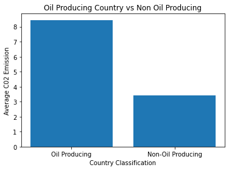

```python
#creating bar chart
locations = [1,2]
heights = [oil_country_emm,no_oil_country_emm]
labels = ['Oil Producing', 'Non-Oil Producing']
plt.bar(locations,heights, tick_label = labels)
plt.title('Oil Producing Country vs Non Oil Producing')
plt.xlabel('Country Classification')
plt.ylabel('Average C02 Emission')
```

**The chart shows visually that oil producing country emits more C02 per person than a non oil-producing country. It infact the average emission of an oil produing country more thn doubles that of a non oil-producing country. This is perhaps expected as the oil producing countries could have oil as their primary energy source and/or consume more than they export to other countries who may not have oil**

### Question 3: How many countries have become more energy efficient since the last 10 years?

**This question seeks to enable us to know how many countries are beginning to adopt cleaner energy in their energy mix. This question will be answered by analyzing the increase or decrease in the C02 emission per person in the last 10 years. A positive difference from the current year shows an increase, hence inefficiency in energy. A negative difference from the current year indicates a decrease in the emission per person while a zero difference shows indifference.**

```python
#Find the difference between the C02 emission in 2010 and 2000
em_dif = df_2010['co2_emission_per_person'] - df_2000['co2_emission_per_person']
df_2010['emission_diff'] = em_dif

#count the number of countries with a negative difference
eff_country = df_2010.query('emission_diff < 0')['country'].nunique
eff_country()
print (eff_country(), ' countries have become more energy efficient since the last 10 years')
```

```
63  countries have become more energy efficient since the last 10 years
```

### Question 4: Which country has had the greatest emission drop for the last 10 years?

**Amongst the 63 countries that have become more energy efficient since the last 10 years, we would like to know which of them tops the table. The country topping the table is simply the country with the minimum emission difference**

```python
#find the minimum emission difference
min_ems = df_2010['emission_diff'].min()
min_ems
```

```
-19.6
```

```python
df_2010.query('emission_diff == -19.6')
```

|  | country | co2_emission_per_person | energy_use_per_person | total_population | total_oil_produce | emission_diff |
| --- | --- | --- | --- | --- | --- | --- |
| 145 | Qatar | 38.8 | 14900.0 | 1860000.0 | 70900000.0 | -19.6 |

**The analysis shows Qatar to be the country with the greatest emission drop since the last 10 years.**

### Question 5: What are the features of a high energy consuming nation?

**This question seeks to reveal some characteristic statically features of a high energy consuming nation with respect to population size, C02 emission. We would like to know the average population of a high energy consuming nation and their averahe co2 emission per person.**

```python
#classify between high energy consuming nations with others.
df_2010['energy_use_per_person'].describe()
```

```
count      201.000000
mean      2293.587065
std       2616.834438
min        135.000000
25%        951.000000
50%       1470.000000
75%       2550.000000
max      17000.000000
Name: energy_use_per_person, dtype: float64
```

**The quartile is a statical term for division of a distribution into 4. The high consuming nations is classified thus as the upper quartile which is the top 25%; here energy value of more than 2550.**

```python
#taking the top quartile has the high consuming nations.
high_energy = df_2010.query('energy_use_per_person >=2550')
low_energy = df_2010.query('energy_use_per_person < 2550')

#average population of an high energy consuming nation
avg_pop_h =high_energy['total_population'].mean()
avg_pop_l =low_energy['total_population'].mean()
print ('The average population of a high energy consuming nation is about ',round(avg_pop_h))
print ('The average population of a low energy consuming nation is about ',round(avg_pop_l))
```

```
The average population of a high energy consuming nation is about  30240996
The average population of a low energy consuming nation is about  36962320
```

```python
#average c02 emission of an high energy consuming nation
avg_ems_h =high_energy['co2_emission_per_person'].mean()
avg_ems_l =low_energy['co2_emission_per_person'].mean()
print ('The average C02 emission of a high energy consuming nation is about ',avg_ems_h)
print ('The average C02 emission of a low energy consuming nation is about ',avg_ems_l)
```

```
The average C02 emission of a high energy consuming nation is about  11.946078431372545
The average C02 emission of a low energy consuming nation is about  2.1446606666666668
```

## Conclusions

**This report shows the analysis done on GapMinder Energy and Emission Data. This work was able to answer specific quuestion including:** **Q1: Do countries with higher population release more of the global emission per person?**

**Q2: Are the non oil producing countries emitting lesser C02 than the oil producing regons?**

**Q3: How many countries have become more energy efficient since the last 10 years?**

**Q4: Which country has had the greatest emission drop for the last 10 years?**

**Q5: What are the features of a high energy consuming nation?**

**It was observed from the exploratory scatter plot analysis that there is no correlation between the population of a country and the amount of C02 emitted.**

**As shown on the bar chart, a low population size had higher C02 emission than a high and dense population size. This further butress the no correlation betwen population size and C02 emission.**

**The result of the analysis also shows that oil producing countries emits more Co2 than non-oil producing nations.**

**High energy consuming nations seem to emit more C02 than low energy consuming nations . The analysis gave a ratio of about 12 to 2. The results also suggests there isn't a correlation between energy consumption per person and total population.**

### Shortcomings and Data Limitation

**Some parts of the data were missing:**

**8 countries do not have recorded C02 emission values. Rather than droppng the rows, the median which signifies the middle possible value was used. This could affect the accuracy of the results.**

**61 countries are absent in the energy use data, the median was used to fill the nulls.**

**NB**: **Non-oil producing nulls are accurate as zeroes.**

References: https://pandas.pydata.org/docs/getting_started/intro_tutorials/03_subset_data.html https://www.statology.org/pandas-merge-multiple-dataframes/ https://stackoverflow.com/questions/51502263/pandas-dataframe-object-has-no-attribute-str https://pandas.pydata.org/pandas-docs/stable/reference/api/pandas.concat.html